# GenoPred Report

Testing mode was used, restricting analyses to chromosome 22.

Sample: example_plink2

Family ID: 4_EAS

Individual ID: 4_EAS

# Target Descriptives

- The target sample contains 12 individuals.
- The target genotype data was provided in plink2 format. Of the 1000 variants in the reference, 1000 were available in the target (100%).

# Ancestry

- The target individual matches the EAS reference population with a probability >50%.

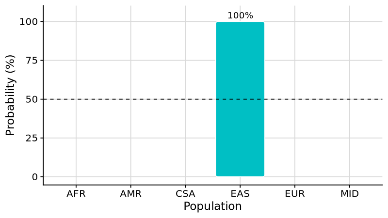

Ancestry inference: Population probabilities.

Note. The dashed line indicates the probability threshold used for ancestry classification.

# Polygenic Scores

- 1 GWAS summary statistics were provided for polygenic scoring.
- 0 GWAS groups were specified.
- 2 PGS methods were applied, including lassosum, pT+clump.
- 1 external score files were provided for polygenic scoring.

## GWAS summary statistics

| Name | Label | Population | NSNP Original | NSNP Final |
| --- | --- | --- | --- | --- |
| BODY04 | Body Mass Index | EUR | 885 | 841 |

**Show GWAS header interpretations**

**BODY04**

| Header | Interpretation |
| --- | --- |
| SNP | RSID for variant |
| A1 | Allele 1 (effect allele) |
| A2 | Allele 2 |
| P | P-value of association |
| BETA | BETA effect size |
| SE | Standard error of log(OR) or BETA |
| N | Total sample size |

**Note.** Columns that were dropped are not shown here.

## Score files

| Name | Label | NSNP Original | NSNP Final | Pass |
| --- | --- | --- | --- | --- |
| PGS002804 | Height Yengo EUR | 708 | 708 | True |

**Note.** The `Pass` column indicates whether a sufficient number of variants within the score file were present in the reference data.

## PGS correlation

This section shows the correlation between PGS in the reference sample. This is intended as a sanity check that the PGS correlations are in the expected direction, thereby confirming the GWAS alleles are being interpreted correctly.

**Show reference PGS correlation matrix**

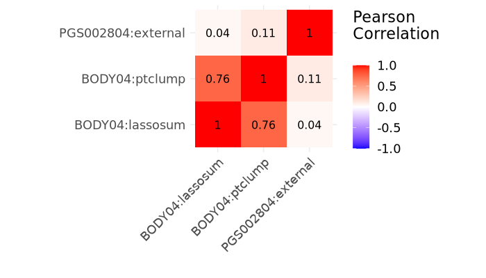

**Note.** Plot shows correlation between pseudovalidated PGS across all populations, adjusted for ancestry.

## Target Polygenic Profile

### Method: lassosum

| Outcome | PGS Descriptives PGS R-squared | PGS Descriptives PGS AUC | Distribution in General Population Prevelance | Distribution in General Population Mean | Distribution in General Population SD | Distribution in People Like You PGS Z-score | Distribution in People Like You Prevalence | Distribution in People Like You Mean | Distribution in People Like You SD |
| --- | --- | --- | --- | --- | --- | --- | --- | --- | --- |
| Body Mass Index | 0 | NA | NA | 0 | 1 | 0.061 | NA | 0 | 1 |

**Note.** PGS R-squared/AUC is estimated via pseudovalidation, and may be inaccurate. To specify alternative parameters, check out our [interactive tool](https://opain.github.io/GenoPred/PRS_to_Abs_tool.html) for converting polygenic scores to the absolute scale.

#### GWAS: Body Mass Index

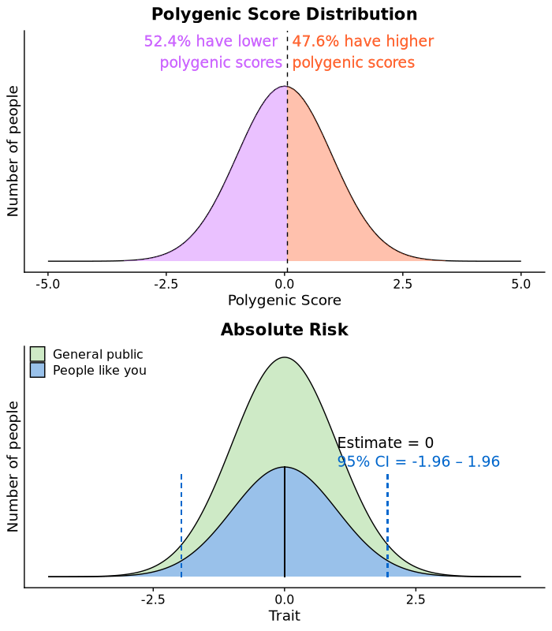

- Your PGS Z-score for Body Mass IndexBody Mass Index is 0.061 which is higher than 52.4% of other EAS individuals.
- Assuming the PGS explains 0% of the variance in Body Mass Index, and the mean and SD of Body Mass Index in the general population is 0 and 1 respectively, on average people with your PGS have a Body Mass Index of 0 (95% CI = -1.96 - 1.96).
- **Note.** These predictions are estimated using a range of assumptions and should be interpreted with caution. This report is merely a demonstration of how polygenic scores can be interpreted.

### Method: pT+clump

| Outcome | PGS Descriptives PGS R-squared | PGS Descriptives PGS AUC | Distribution in General Population Prevelance | Distribution in General Population Mean | Distribution in General Population SD | Distribution in People Like You PGS Z-score | Distribution in People Like You Prevalence | Distribution in People Like You Mean | Distribution in People Like You SD |
| --- | --- | --- | --- | --- | --- | --- | --- | --- | --- |
| Body Mass Index | 0 | NA | NA | 0 | 1 | 1.27 | NA | 0 | 1 |

**Note.** PGS R-squared/AUC is estimated via pseudovalidation, and may be inaccurate. To specify alternative parameters, check out our [interactive tool](https://opain.github.io/GenoPred/PRS_to_Abs_tool.html) for converting polygenic scores to the absolute scale.

#### GWAS: Body Mass Index

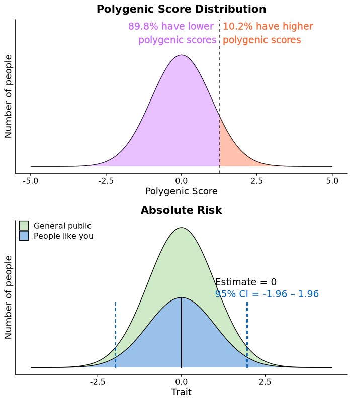

- Your PGS Z-score for Body Mass IndexBody Mass Index is 1.27 which is higher than 89.8% of other EAS individuals.
- Assuming the PGS explains 0% of the variance in Body Mass Index, and the mean and SD of Body Mass Index in the general population is 0 and 1 respectively, on average people with your PGS have a Body Mass Index of 0 (95% CI = -1.96 - 1.96).
- **Note.** These predictions are estimated using a range of assumptions and should be interpreted with caution. This report is merely a demonstration of how polygenic scores can be interpreted.

This report was created using GenoPred (v2.2.2-312-g61d3a33).